# Títulos y etiquetas de ejes

### Agregar un título

Para agregar un título a tu gráfico, añade el código `+ggtitle("Tu título aquí")` a tu línea de código básico de ggplot. Asegúrate de utilizar comillas al inicio y al final de tu título.

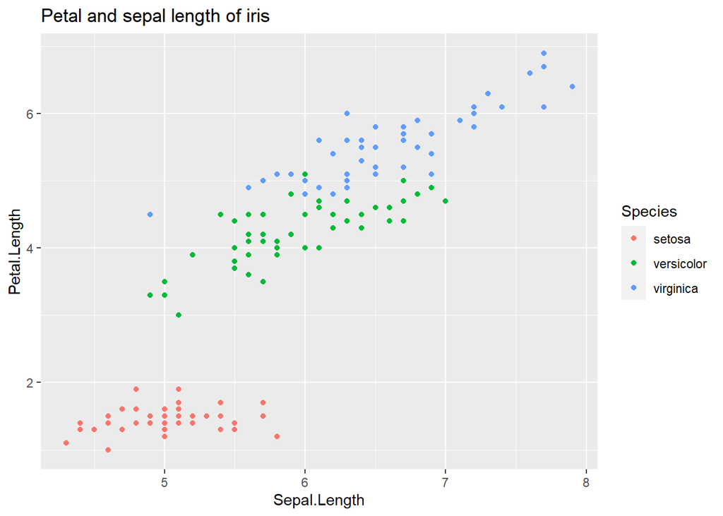

```r
print(IrisPlot + ggtitle("Petal and sepal length of iris"))
```

Si tienes un título especialmente largo que funcionaría mejor en dos líneas, utiliza `\n` para hacer un salto de línea. Asegúrate de utilizar la barra diagonal correcta.

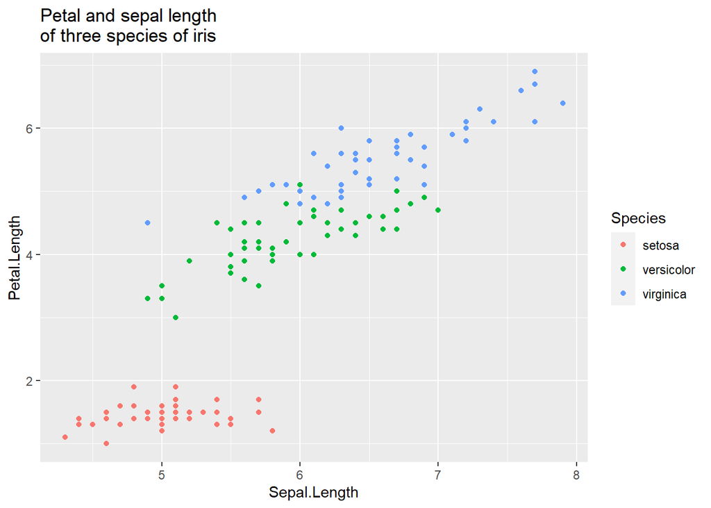

```r
print(IrisPlot + ggtitle("Petal and sepal length \nof three species of iris"))
```

### Cambiar las etiquetas de los ejes

Para modificar las etiquetas de los ejes, añade el código `+labs(y = "nombre del eje y", x = "nombre del eje x")` a tu línea de código básico de ggplot.

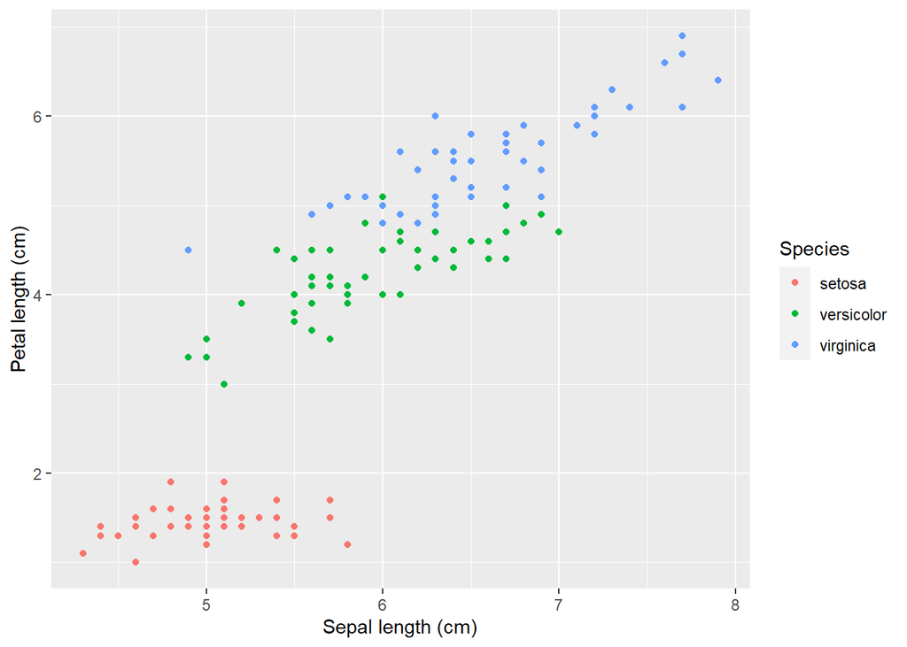

```r
print(IrisPlot + labs(y = "Petal length (cm)", x = "Sepal length (cm)"))
```

Nota: También puedes usar `+labs(title = "Título")`, que es equivalente a `ggtitle`.

Por ejemplo:

```r
print(IrisPlot + labs(
  title = "Petal and Sepal Length \nof Iris",
  y = "Petal Length (cm)", x = "Sepal Length (cm)"
))
```

### Cambiar el título de la leyenda

De la misma manera que editaste el título y los nombres de los ejes, puedes modificar el título de la leyenda agregando `+labs(colour = "Título de la leyenda")` al final de tu código básico de trazado.

Nota: Esto solo funcionará si realmente has añadido una variable adicional a tu código `aes` (en este caso, utilizando `color = Species` para agrupar los puntos por especie).

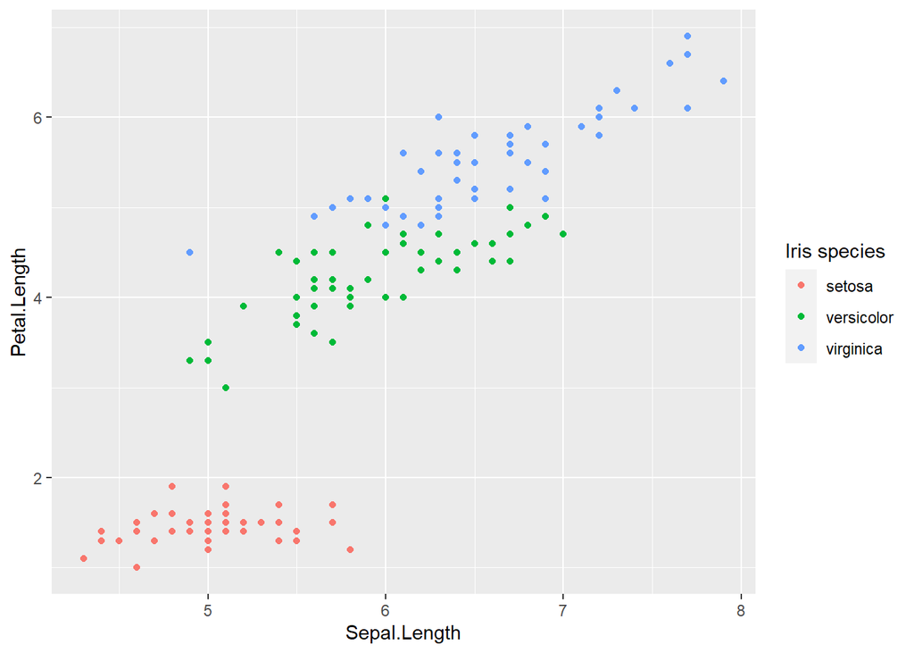

```r
IrisPlot <- ggplot(iris, aes(Sepal.Length, Petal.Length, colour = Species)) +
  geom_point()

print(IrisPlot + labs(colour = "Iris species"))
```

Nota: Si estás utilizando un histograma, diagrama de caja o gráfico de barras, es ligeramente diferente. Debes usar `fill` en lugar de `colour`.

```r
IrisBox <- ggplot(iris, aes(Species, Sepal.Length, fill = Species)) +
  geom_boxplot()
print(IrisBox + labs(fill = "Iris species"))
```

### Modificando el estilo del texto en la leyenda, ejes o título

Se pueden modificar la fuente, color, tamaño y énfasis de las etiquetas y texto. Para hacer esto, utiliza el código `theme()` y personalízalo con `element_text()` para modificar estas propiedades.

El formato básico es: `mi_tema <- theme(tipo_de_título = element_text(tus_formatos))`

Donde “tipo_de_título” especifica qué texto en particular deseas editar. Estos pueden ser:

- título del gráfico. - `plot.title = element_text()`
- título del eje. - `axis.title = element_text()`
- título de la leyenda. - `legend.title = element_text()`
- categorías de la leyenda - `legend.text = element_text()`
- apariencia de los valores/números del eje. - `axis.text = element_text()`

**Opciones de formato** La fuente, color, tamaño y énfasis de cualquiera de estas etiquetas se pueden modificar con argumentos dentro de `element_text(tu_formato)`.

- family. - el estilo de fuente. Ejemplos de fuentes incluyen: “Palatino”, “Helvetica”, “Courier”, “Times”. Puedes ver más opciones de fuente [aquí](http://www.cookbook-r.com/Graphs/Fonts/). Por ejemplo, `family = "Palatino"`
- face. - el tipo de énfasis, con opciones que incluyen **bold** (negrita), *italic* (cursiva) y “bold.italic” (negrita cursiva). Por ejemplo, `face = "bold.italic"`
- colour. - el color se puede cambiar a cualquiera de los colores listados [aquí](http://www.stat.columbia.edu/~tzheng/files/Rcolor.pdf). Recuerda incluir “” antes y después del nombre del color. Por ejemplo, `colour = "steelblue2"`.
- size. - el tamaño del texto, especificado con un número. Por ejemplo, `size = (3)`.

### Código de ejemplo

Aquí tienes un ejemplo de un tema que personaliza el título, la leyenda, las etiquetas de los ejes y especifica la fuente, énfasis, tamaño y color de cada uno de ellos. La figura se traza con este tema y con código adicional que proporciona el contenido del título y las etiquetas de los ejes:

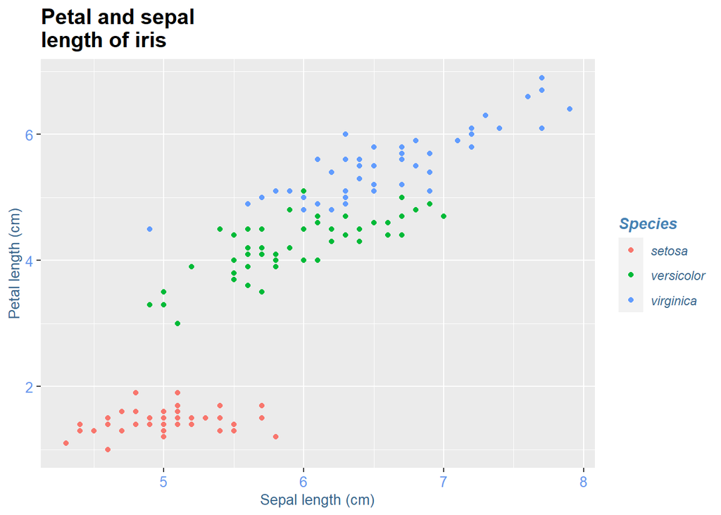

```r
mynamestheme <- theme(
  plot.title = element_text(family = "Helvetica", face = "bold", size = (15)),
  legend.title = element_text(colour = "steelblue", face = "bold.italic", family = "Helvetica"),
  legend.text = element_text(face = "italic", colour = "steelblue4", family = "Helvetica"),
  axis.title = element_text(family = "Helvetica", size = (10), colour = "steelblue4"),
  axis.text = element_text(family = "Courier", colour = "cornflowerblue", size = (10))
)

print(IrisPlot + mynamestheme + labs(title = "Petal and sepal \nlength of iris", y = "Petal length (cm)", x = "Sepal length (cm)"))
```

### Eliminación de una etiqueta

Otra opción es eliminar completamente el texto del gráfico. Para hacer esto, utiliza el código `= element_blank()`, recordando los paréntesis abiertos y cerrados. El siguiente código eliminaría el título de la leyenda y el texto del eje.

```r
myblanktheme <- theme(
  plot.title = element_text(family = "Helvetica", face = "bold", size = (15)),
  legend.title = element_blank(),
  legend.text = element_text(face = "italic", colour = "steelblue4", family = "Helvetica"),
  axis.title = element_text(family = "Helvetica", size = (10), colour = "steelblue4"),
  axis.text = element_blank()
)

print(IrisPlot + myblanktheme + labs(title = "Petal and sepal \nlength of iris", y = "Petal length (cm)", x = "Sepal length (cm)"))
```

### Más ayuda

Para personalizar aún más la estética del gráfico, incluyendo el color y el formato, consulta nuestras otras páginas de ayuda de ggplot: * Modificar la apariencia general. * Colores y símbolos.

Puedes encontrar ayuda sobre todas las funciones de ggplot en [el sitio principal de ayuda de ggplot](https://ggplot2.tidyverse.org).

Una hoja de referencia útil sobre las funciones comúnmente utilizadas se puede descargar [aquí](https://raw.githubusercontent.com/rstudio/cheatsheets/main/data-visualization.pdf).

Chang, W (2012) *R Graphics cookbook.* O’Reilly Media. - una guía de ggplot con bastante ayuda en línea [aquí](http://www.cookbook-r.com/Graphs/)

**Autor**: Fiona Robinson

**Año**: 2016

**Última actualización**: Jun. 2023